# MidProject slides

```python
import numpy as np
import pandas as pd
import seaborn as sns
import matplotlib
import matplotlib.pyplot as plt


df = pd.read_csv('feedback.csv')
```

```python
df
```

|  | ID | Location | Track | Week | Rating (Num) | Schedule Pacing |
| --- | --- | --- | --- | --- | --- | --- |
| 0 | 134 | San Francisco | Apps, Explorer | Week 1 | 3 | Just right |
| 1 | 36 | Los Angeles | Apps | Week 1 | 4 | A little too fast |
| 2 | 117 | San Francisco | Games | Week 1 | 4 | Way too slow |
| 3 | 253 | NaN | NaN | Week 2 | 4 | A little too fast |
| 4 | 350 | New York City | Apps, Explorer | Week 1 | 4 | Just right |
| ... | ... | ... | ... | ... | ... | ... |
| 1448 | 1495 | New York City | Apps, Explorer | Week 7 | 10 | Just right |
| 1449 | 1496 | New York City | Apps, Explorer | Week 7 | 8 | Just right |
| 1450 | 1497 | New York City | Apps | Week 7 | 10 | Just right |
| 1451 | 1498 | New York City | Apps, Explorer | Week 7 | 1 | A little too slow |
| 1452 | 1499 | New York City | Apps | Week 5 | 8 | Just right |

1453 rows × 6 columns

```python
pd.options.mode.chained_assignment = None
df.columns = ['ID', 'Location', 'Track', 'Week', 'Rating', 'Pacing']
df['Rating'] = df['Rating'][df['Rating']!='#ERROR!']
df['Rating'].value_counts()
```

```
8     392
9     384
10    376
7     177
6      59
5      35
4      13
3       8
0       2
1       2
2       2
Name: Rating, dtype: int64
```

# Question 1: How do the student's ratings change over the length of the course?

```python
df = df.dropna()
df['Rating'] = df['Rating'].astype(int)
pd.crosstab(df['Week'], df['Rating'])
```

| Rating Week | 0 | 1 | 2 | 3 | 4 | 5 | 6 | 7 | 8 | 9 | 10 |
| --- | --- | --- | --- | --- | --- | --- | --- | --- | --- | --- | --- |
| Week 1 | 0 | 0 | 0 | 1 | 6 | 9 | 10 | 39 | 89 | 56 | 66 |
| Week 2 | 0 | 0 | 0 | 2 | 0 | 6 | 11 | 31 | 80 | 74 | 57 |
| Week 3 | 0 | 1 | 0 | 1 | 0 | 4 | 13 | 19 | 63 | 69 | 63 |
| Week 4 | 0 | 0 | 0 | 2 | 3 | 6 | 8 | 23 | 49 | 55 | 43 |
| Week 5 | 1 | 0 | 1 | 0 | 2 | 3 | 7 | 22 | 45 | 44 | 51 |
| Week 6 | 0 | 0 | 1 | 1 | 0 | 1 | 5 | 18 | 41 | 34 | 42 |
| Week 7 | 0 | 1 | 0 | 1 | 0 | 4 | 2 | 14 | 19 | 41 | 37 |
| Week 8 | 0 | 0 | 0 | 0 | 0 | 0 | 0 | 1 | 1 | 3 | 4 |

```python
df
```

|  | ID | Location | Track | Week | Rating | Pacing |
| --- | --- | --- | --- | --- | --- | --- |
| 0 | 134 | San Francisco | Apps, Explorer | Week 1 | 3 | Just right |
| 1 | 36 | Los Angeles | Apps | Week 1 | 4 | A little too fast |
| 2 | 117 | San Francisco | Games | Week 1 | 4 | Way too slow |
| 4 | 350 | New York City | Apps, Explorer | Week 1 | 4 | Just right |
| 5 | 23 | Redwood City | Apps | Week 1 | 5 | Just right |
| ... | ... | ... | ... | ... | ... | ... |
| 1448 | 1495 | New York City | Apps, Explorer | Week 7 | 10 | Just right |
| 1449 | 1496 | New York City | Apps, Explorer | Week 7 | 8 | Just right |
| 1450 | 1497 | New York City | Apps | Week 7 | 10 | Just right |
| 1451 | 1498 | New York City | Apps, Explorer | Week 7 | 1 | A little too slow |
| 1452 | 1499 | New York City | Apps | Week 5 | 8 | Just right |

1406 rows × 6 columns

```python
total = 0
total_list = []
def get_sums():
    for i in range(1, len(df['Week'].value_counts()) + 1):
        total = 0
        for j in range(0, len(df['Rating'].value_counts())):
            total += j * len(df[(df['Week'] == f'Week {i}') & (df['Rating'] == j)])
        total_list.append(round(total/len(df[df['Week'] == f'Week {i}']),3))
    return total_list

ratings = get_sums()
weeks = ['Week 1', 'Week 2', 'Week 3', 'Week 4', 'Week 5', 'Week 6', 'Week 7', 'Week 8']
```

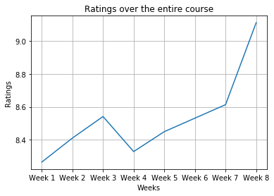

```python
fig, ax = plt.subplots()
ax.plot(weeks, ratings)

ax.set(xlabel='Weeks', ylabel='Ratings',
       title='Ratings over the entire course')
ax.grid()
plt.show()
```

## Although there is a trend upwards in the graph, the last week is an outlier with the small amount of people who filled out a response. Overall the ratings stayed consistent throughout the courses.

# Question 2: What is the breakdown of where students are from, and from that, which track is the most popular from the top location compared to the rest of the students.

```python
df['Location'].value_counts()
```

```
San Francisco    360
New York City    330
Santa Clara      201
Los Angeles      106
Beijing           78
Chicago           70
Tokyo             65
Redwood City      58
Oakland           47
Washington DC     47
Atlanta           33
Hong Kong         11
Name: Location, dtype: int64
```

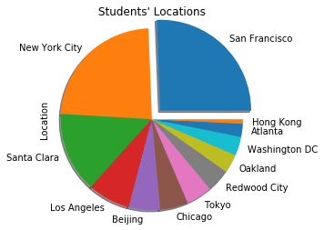

```python
explode = (0.15, 0, 0, 0, 0, 0, 0, 0, 0, 0, 0 ,0)
df['Location'].value_counts().plot(kind='pie', title="Students' Locations", explode=explode, shadow=True, radius=1.15)
```

```python
df['Location'].value_counts()
```

```
San Francisco    360
New York City    330
Santa Clara      201
Los Angeles      106
Beijing           78
Chicago           70
Tokyo             65
Redwood City      58
Oakland           47
Washington DC     47
Atlanta           33
Hong Kong         11
Name: Location, dtype: int64
```

```python
df[df['Location'] == 'San Francisco']['Track'].value_counts()
```

```
Apps              155
Apps, Explorer     77
Games              68
VR                 60
Name: Track, dtype: int64
```

```python
df['Track'].value_counts()
```

```
Apps               871
Apps, Explorer     224
Games              208
VR                  60
Games, Explorer     43
Name: Track, dtype: int64
```

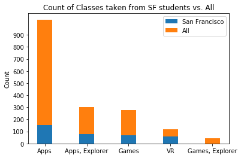

```python
N = 5
sf_classes = (155, 77, 68, 60, 0)
all_classes = (871, 224, 208, 60, 43)
ind = np.arange(N)    # the x locations for the groups
width = 0.35       # the width of the bars: can also be len(x) sequence

p1 = plt.bar(ind, sf_classes, width)
p2 = plt.bar(ind, all_classes, width,
             bottom=sf_classes)

plt.ylabel('Count')
plt.title('Count of Classes taken from SF students vs. All')
plt.xticks(ind, ('Apps', 'Apps, Explorer', 'Games', 'VR', 'Games, Explorer'))
plt.yticks(np.arange(0, 1000, 100))
plt.legend((p1[0], p2[0]), ('San Francisco', 'All'))

plt.show()
```

## Out of all the cities, San Francisco is the one on top. The top track picked by students from SF is Apps, same trend for the rest of Students at Make School. Also the only students who took the VR Track were from San Francisco.

# Q3: In the top track category [Apps], what were the student's thoughts on the pacing of the courses?

```python
def apps_pacing():
    pacing = df[df['Track'] == 'Apps']['Pacing']
    just_right, too_slow, too_fast, little_slow, little_fast = 0, 0, 0, 0, 0
    for pace in pacing:
        #NA values
        try:
            pacing = str(pacing)
        except ValueError:
            break
        if pace == 'Just right':
            just_right +=1
        elif pace == 'Way too slow':
            too_slow += 1
        elif pace == 'Way too fast':
            too_fast += 1
        elif pace == 'A little too slow':
            little_slow += 1
        else:
            little_fast += 1
    return [just_right, too_slow, too_fast, little_slow, little_fast]
apps_pacing()
```

```
[603, 0, 13, 58, 197]
```

```python
df[df['Track'] == 'Apps']['Pacing'].iloc[150:200]
```

```
249           Just right
250           Just right
251    A little too fast
252           Just right
254           Just right
255           Just right
257           Just right
259           Just right
260    A little too fast
263           Just right
264           Just right
265           Just right
266           Just right
267           Just right
269    A little too fast
```

[output cut: 36 more lines]

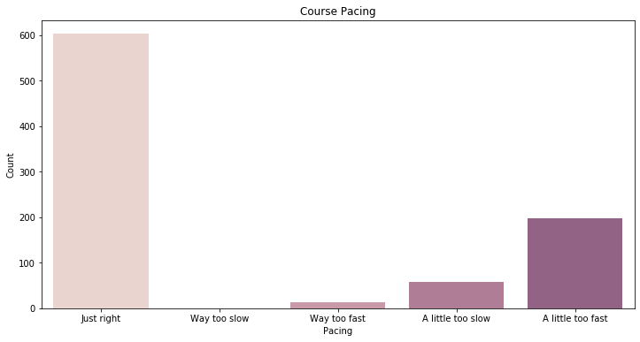

```python
df2 = pd.DataFrame()

df2['Pacing'] = ['Just right', 'Way too slow', 'Way too fast', 'A little too slow', 'A little too fast']
df2['Count'] = apps_pacing()
plt.figure(figsize=(12, 6))
ax = sns.barplot(x="Pacing", y="Count", data=df2,
                 palette=sns.cubehelix_palette(8)).set_title('Course Pacing')
```

## In summary most people think the apps class pacing was just right. Interestingly not a single person said the apps class was way too slow.

# Q4: What courses had the highest amount of promoters?

```python
def promoters():
    scores = {}
    tracks = ['Apps', 'Apps, Explorer', 'Games', 'VR', 'Games, Explorer']
    for track in tracks:
        apps_rating = df[df['Track'] == track]['Rating']
        for rating in apps_rating:
            #NA values
            try:
                rating = int(rating)
            except ValueError:
                break
            if rating >= 9:
                if track not in scores:
                    scores[track] = scores.get(track, 1)
                else:
                    scores[track] += 1
    return scores
promoters()['Apps']
```

```
438
```

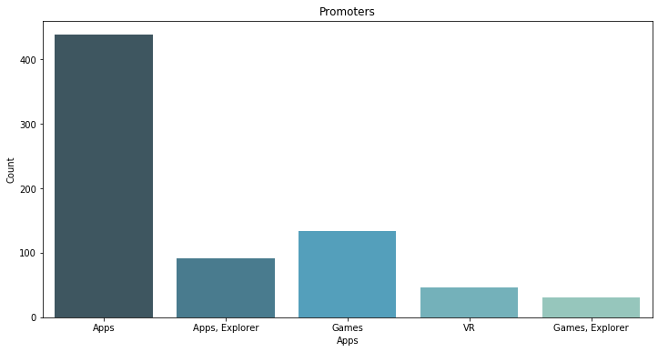

```python
df3 = pd.DataFrame()

df3['Apps'] = ['Apps', 'Apps, Explorer', 'Games', 'VR', 'Games, Explorer']
df3['Count'] = promoters()['Apps'], promoters()['Apps, Explorer'], promoters()['Games'], promoters()['VR'], promoters()['Games, Explorer']
plt.figure(figsize=(12, 6))
ax = sns.barplot(x="Apps", y="Count", data=df3,
                 palette="GnBu_d").set_title('Promoters')
```

# Apps turns out to have the most promoters by a long shot with Games, Explorer being the least.

# Q5: What is the NPS score of the courses?

```python
df
```

[output not shown]

1406 rows × 8 columns

```python
df = df.drop(columns="Support")
```

```python
df['Type'] = 'Detractor'
df.loc[df['Rating'] >= 9, 'Type'] = 'Promoter'
df.loc[(df['Rating'] >= 7) & (df['Rating'] <= 8), 'Type'] = 'Passive'
df.loc[df['Rating'] <= 6, 'Type'] = 'Detractor'
df.head()
```

|  | ID | Location | Track | Week | Rating | Pacing | Type |
| --- | --- | --- | --- | --- | --- | --- | --- |
| 0 | 134 | San Francisco | Apps, Explorer | Week 1 | 3 | Just right | Detractor |
| 1 | 36 | Los Angeles | Apps | Week 1 | 4 | A little too fast | Detractor |
| 2 | 117 | San Francisco | Games | Week 1 | 4 | Way too slow | Detractor |
| 4 | 350 | New York City | Apps, Explorer | Week 1 | 4 | Just right | Detractor |
| 5 | 23 | Redwood City | Apps | Week 1 | 5 | Just right | Detractor |

```python
promoter = len(df[df['Type'] == 'Promoter'])
passive = len(df[df['Type'] == 'Passive'])
detractor = len(df[df['Type'] == 'Detractor'])
```

```python
def NPS(promo, passi, detra):
    return round((promo - detra) / (promo + passi + detra) * 100, 3)

print('NPS {}'.format(NPS(promoter, passive, detractor)))
```

```
NPS 44.523
```

# The NPS for this data is 44.523